# min_max_correlation

## Jane Street - min max correlation problem

For arbitrary random variables X1, X2, ..., Xn, find min max corr(Xi,Xj).

#### My solution:

1. Consider the correlation matrix of X1, X2, ..., Xn
2. In n = 2 case, easy to see min(X1, X2) = -1
3. In n = 3 case, if we set corr(X1, X2) = a(r.v. between -1 and 1), corr(X1, X3) = b, then corr(X1, X3) = has a boundary.

3.1 Imagine correlation of 3 r.v. as vectors in 3-d space, our guess is that min can be attained when the spread angle between each pair of vectors are the same. At this time min max correlation = -1/2.

3.2 Solve numerically, we get upper/lower bound of a *b +/- sqrt(1-a**2)* sqrt(1-b**2). Then solve max(corr(X1, X2), corr(X1, X3), corr(X1, X3)) for every pair(a,b) and draw a surface to find min point to be -1/2.

```python
import numpy as np

a = np.arange(-1,1,0.05)
b = np.arange(-1,1,0.05)
# formula : a * b +/- sqrt(1-a**2)*sqrt(1-b**2)
upper_bound = np.matrix(a).transpose() * np.matrix(b) + np.matrix((np.sqrt(1-a**2))).transpose() * np.matrix(np.sqrt(1-b**2))
lower_bound = np.matrix(a).transpose() * np.matrix(b) - np.matrix((np.sqrt(1-a**2))).transpose() * np.matrix(np.sqrt(1-b**2))
dim = len(a)
max_corr = np.ones((dim, dim))
for i in range(dim):
    for j in range(dim):
        max_corr[i][j] = max(a[i],b[j],np.array(lower_bound)[i][j])
print(max_corr)
```

```
[[ 1.          0.95        0.9        ...,  0.85        0.9         0.95      ]
 [ 0.95        0.805       0.71889342 ...,  0.85        0.9         0.95      ]
 [ 0.9         0.71889342  0.62       ...,  0.85        0.9         0.95      ]
 ...,
 [ 0.85        0.85        0.85       ...,  0.85        0.9         0.95      ]
 [ 0.9         0.9         0.9        ...,  0.9         0.9         0.95      ]
 [ 0.95        0.95        0.95       ...,  0.95        0.95        0.95      ]]
```

```python
import plotly
import plotly.plotly as py
import plotly.figure_factory as ff
import pandas as pd
from plotly.graph_objs import Surface

plotly.tools.set_credentials_file(username='dlu-umich', api_key='nKT09bi9qd36GJbrIEjz')
```

```python
py.iplot([
    dict(z=upper_bound, type='surface'),
    dict(z=lower_bound, showscale=False, opacity=0.9, type='surface')])
    #dict(z=max_corr, showscale=False, opacity=0.9, type='surface')])
    #filename = 'python-docs/multiple-surfaces')
```

[interactive chart not shown]

```python
py.iplot([
    dict(z=max_corr, showscale=False, opacity=0.9, type='surface')])
    #filename = 'python-docs/multiple-surfaces')
```

[interactive chart not shown]

3.3 Run simulation of arbitrary r.v. X1, X2, X3 to see what the min max corr plot like.

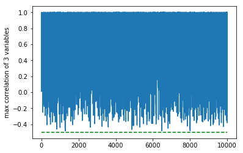

```python
# run simulation to x1 x2 x3 in three dimensions
import matplotlib.pyplot as plt

simu = []
h = 3
num_simu = 10000
for _ in range(num_simu):
    x1 = np.random.random(size=h)
    x2 = np.random.random(size=h)
    x3 = np.random.random(size=h)
    a12 = np.corrcoef(x1,x2)[0][1]
    a13 = np.corrcoef(x1,x3)[0][1]
    a23 = np.corrcoef(x2,x3)[0][1]
    max_corr = max(a12,a13,a23)
    simu.append(max_corr)
plt.plot(simu)
plt.ylabel('max correlation of 3 variables')
xs = np.linspace(1,num_simu+1,num_simu)
horiz_line_data = np.array([-1/2 for i in range(len(xs))])
plt.plot(xs, horiz_line_data, 'g--')

plt.show()
```

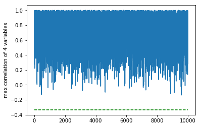

```python
# run simulation to x1 x2 x3 x4 in four dimensions
simu4 = []
h = 4
num_simu = 10000
for _ in range(num_simu):
    x1 = np.random.random(size=h)
    x2 = np.random.random(size=h)
    x3 = np.random.random(size=h)
    x4 = np.random.random(size=h)

    a12 = np.corrcoef(x1,x2)[0][1]
    a13 = np.corrcoef(x1,x3)[0][1]
    a14 = np.corrcoef(x1,x4)[0][1]
    a23 = np.corrcoef(x2,x3)[0][1]
    a24 = np.corrcoef(x2,x4)[0][1]
    a34 = np.corrcoef(x3,x4)[0][1]

    max_corr = max(a12,a13,a14,a23,a24,a34)
    simu4.append(max_corr)

plt.plot(simu4)
plt.ylabel('max correlation of 4 variables')

xs = np.linspace(1,num_simu+1,num_simu)
horiz_line_data = np.array([-1/3 for i in range(len(xs))])
plt.plot(xs, horiz_line_data, 'g--')

plt.show()
```

4 In n >= 4 cases, we continue the guess that the min max correlation can be attained when spread angle between every pair of vectors be the same. This is reasonable because of geometry, and the min spread angle can be calculated in an n-dim polyhedron.

##### Key is -1/(n-1).

# # # # # #

[figure not shown]

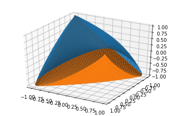

```python
import matplotlib.pyplot as plt
from mpl_toolkits.mplot3d import Axes3D
from matplotlib import cm
from matplotlib.ticker import LinearLocator, FormatStrFormatter

xa, xb = np.meshgrid(a, b)
fig = plt.figure()
ax = fig.gca(projection='3d')
ax.invert_yaxis()
surf1 = ax.plot_surface(xa,xb,upper_bound)
surf2 = ax.plot_surface(xa,xb,lower_bound)
plt.show()
```

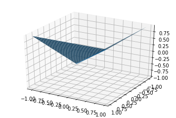

```python
fig = plt.figure()
ax = fig.gca(projection='3d')
ax.invert_yaxis()
maxab = np.ones((dim, dim))
for i in range(dim):
    for j in range(dim):
        maxab[i][j] = max(a[i],b[j])
surf3 = ax.plot_surface(xa,xb,maxab)
plt.show()
```

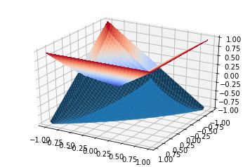

```python
fig = plt.figure()
ax = fig.gca(projection='3d')
ax.invert_yaxis()
# surf1 = ax.plot_surface(a,b,upper_bound)
surf5 = ax.plot_surface(xa,xb,lower_bound)
surf6 = ax.plot_surface(xa,xb,max_corr,cmap=cm.coolwarm,
                       linewidth=0, antialiased=False)
#fig.colorbar(surf1, shrink=0.5, aspect=5)
plt.show()
```

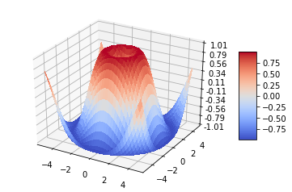

```python
fig = plt.figure()
ax = fig.gca(projection='3d')

# Make data.
X = np.arange(-5, 5, 0.25)
Y = np.arange(-5, 5, 0.25)
X, Y = np.meshgrid(X, Y)
R = np.sqrt(X**2 + Y**2)
upper_bound = np.sin(R)

# Plot the surface.
surf = ax.plot_surface(X, Y, upper_bound, cmap=cm.coolwarm,
                       linewidth=0, antialiased=False)

# Customize the z axis.
ax.set_zlim(-1.01, 1.01)
ax.zaxis.set_major_locator(LinearLocator(10))
ax.zaxis.set_major_formatter(FormatStrFormatter('%.02f'))

# Add a color bar which maps values to colors.
fig.colorbar(surf, shrink=0.5, aspect=5)

plt.show()
```

```python
z1 = [
    [8.83,8.89,8.81,8.87,8.9,8.87],
    [8.89,8.94,8.85,8.94,8.96,8.92],
    [8.84,8.9,8.82,8.92,8.93,8.91],
    [8.79,8.85,8.79,8.9,8.94,8.92],
    [8.79,8.88,8.81,8.9,8.95,8.92],
    [8.8,8.82,8.78,8.91,8.94,8.92],
    [8.75,8.78,8.77,8.91,8.95,8.92],
    [8.8,8.8,8.77,8.91,8.95,8.94],
    [8.74,8.81,8.76,8.93,8.98,8.99],
    [8.89,8.99,8.92,9.1,9.13,9.11],
    [8.97,8.97,8.91,9.09,9.11,9.11],
    [9.04,9.08,9.05,9.25,9.28,9.27],
    [9,9.01,9,9.2,9.23,9.2],
    [8.99,8.99,8.98,9.18,9.2,9.19],
    [8.93,8.97,8.97,9.18,9.2,9.18]
]

z2 = [[zij+1 for zij in zi] for zi in z1]
z3 = [[zij-1 for zij in zi] for zi in z1]

py.iplot([
    dict(z=z1, type='surface'),
    dict(z=z2, showscale=False, opacity=0.9, type='surface'),
    dict(z=z3, showscale=False, opacity=0.9, type='surface')],
    filename='python-docs/multiple-surfaces')
```

[output not shown]

[output not shown]